# Using scPNMF for gene selection and data projection

Dongyuan Song and Kexin Li

Bioinformatics IDP, University of California, Los Angeles  
Department of Statistics, University of California, Los Angeles

8 February 2021

# 1 Introduction

```r
suppressPackageStartupMessages(library(scPNMF))
suppressPackageStartupMessages(library(SingleCellExperiment))
suppressPackageStartupMessages(library(umap))
suppressPackageStartupMessages(library(ggplot2))
```

*scPNMF* is a method to facilitate gene selection for targeted gene profiling by learning a sparse gene encoding of single cells. Compared with existing gene selection methods, *scPNMF* has two advantages. First, its selected informative genes can better distinguish cell types, with a small number, e.g., < 200 gene. Second, it enables the alignment of new targeted gene profiling data with reference data in a low-dimensional space to help the prediction of cell types in the new data.

In this manual, we will demonstrate how to use *scPNMF* package to select informative genes, and project datasets with limited gene numbers (e.g., targeted gene profiling) into a low-dimensional space.

# 2 Setting Up the Data

Here we use `zheng4` dataset as an example. The `zheng4` dataset is stored as an `SingleCellExperiment` object. Unlike other single-cell methods, *scPNMF* **DO NOT** require normalization (e.g., normalized by cell library size). The input data is simply the raw log-count matrix, where rows are genes and columns are cells.

```r
data(zheng4, package = "scPNMF")
Input_zheng4 <- logcounts(zheng4)
```

The input data contains 2192 genes and 3994 cells.

# 3 Step I: PNMF

The first step is to run the Projective Nonnegative Matrix Factorization (PNMF). Briefly, PNMF takes advantages from both PCA and NMF (as its name!). Here is a table comparing PNMF with PCA and NMF.

| Method | Optimization Problem | Non-negativity | Sparsity | Mutually Exclusiveness | New Data Projection |
| --- | --- | --- | --- | --- | --- |
| PNMF | $\min\limits_{\mathbf{W}} \\|\mathbf{X} - \mathbf{W}\mathbf{W}^T\mathbf{X}\\|\ s.t.\ \mathbf{W}\geq 0$ | Yes | Very high | Very high | Yes |
| PCA | $\min\limits_{\mathbf{W}} \\|\mathbf{X} - \mathbf{W}\mathbf{W}^T\mathbf{X}\\|\ s.t.\ \mathbf{W}^T\mathbf{W} = \mathbf{I}$ | No | Low | Low | Yes |
| NMF | $\min\limits_{\mathbf{W}, \mathbf{H}} \\|\mathbf{X} - \mathbf{W}\mathbf{H}\\|\ s.t.\ \mathbf{W},\mathbf{H}\geq 0$ | Yes | High | High | No |

We run the PNMF algorithm. $K$, the number of low dimension, is a key parameter that needs to be pre-specified by users. For a typical scRNA-seq data, $K=20$ is recommended in our *scPNMF* paper. Here we set $K=15$ for demonstration purpose.

```r
res_pnmf <- scPNMF::PNMFfun(X = Input_zheng4,
                            K = 15, method="EucDist", tol=1e-4, maxIter=1000, verboseN = TRUE)
```

```
## 100 iterations used.
## 200 iterations used.
## 300 iterations used.
## 400 iterations used.
## 500 iterations used.
## 600 iterations used.
## 700 iterations used.
## 800 iterations used.
## 900 iterations used.
## 1000 iterations used.
```

```r
W <- res_pnmf$Weight
S <- res_pnmf$Score
```

The output is a list containing two matrices: the weight matrix (projection matrix) $\mathbf{W}$ and the score matrix (low-dimensional space) $\mathbf{S} = \mathbf{W}^T\mathbf{X}$. The two output matrices are very similar as those from PCA.

# 4 Step II: Basis Selection

The second main step of *scPNMF* is to select informative bases among the $K$ bases found by PNMF in the last step(i.e., columns of $\mathbf{W}$ and rows of $\mathbf{S}$). The main goal is to remove unwanted variations of cells (e.g., variations irrelevant to cell types). There are three main strategies: functional annotations (optional); data-driven basis selection: correlations with cell library sizes and multimodality tests. We have designed functions for each strategy, and finally we show how to perform basis selection with regard to all the strategies by a combined function.

## 4.1 Functional Annotations

Due to the nice interpretability of PNMF, each basis briefly represents a funtional gene cluster. Users can perform Gene Ontology (GO) analysis to annoate each basis, and decide which bases they believe are useless and remove irrelevant bases. This is an **OPTIONAL** step since it requires prior knowledge from users. Here we demonstrate functional annotations on the first five bases by setting `dim_use = 1:5`.

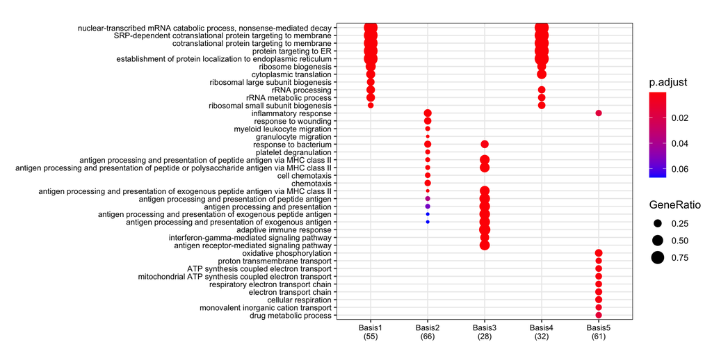

```r
res_annotation <- scPNMF::basisAnnotate(W = W,
                                        dim_use = 1:5,
                                        id_type = "ENSEMBL",
                                        return_fig = TRUE)
plot(res_annotation$p_comp)
```

## 4.2 Data-driven Selection (Correlations with Cell Library Sizes and Multimodality Tests)

The default basis selection procedure in *scPNMF* is purely data-driven. We have two basic assumptions: 1. A basis which is highly correlated with cell library size (here, total log-counts) should be removed since researchers usually treat cell library size as an unwanted variation; 2. A basis which shows strong multi-modal pattern should be kept since it indicates cell sub-population (e.g., cell type) structure.

The following function will perform the basis check and users can inspect the checking result by setting `return_fig = TRUE`.

```r
res_test <- scPNMF::basisTest(S = S, X = Input_zheng4,
                              return_fig = TRUE, ncol = 5,
                              mc.cores = 1)
```

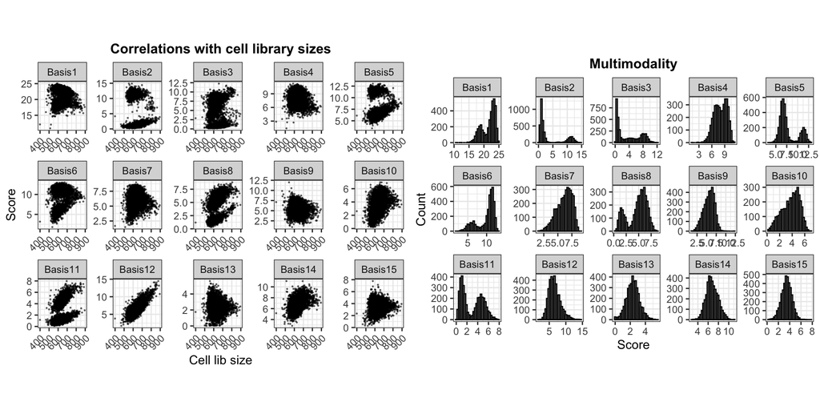

## 4.3 Combined Basis Selection Function

The following wrapper function will select bases automatically.

```r
W_select <- scPNMF::basisSelect(W = W, S = S,
                                X=Input_zheng4, toTest = TRUE, toAnnotate = FALSE, mc.cores = 1)
colnames(W_select)
```

```
##  [1] "Basis1"  "Basis2"  "Basis3"  "Basis4"  "Basis5"  "Basis6"  "Basis7"
##  [8] "Basis8"  "Basis9"  "Basis10" "Basis11" "Basis13" "Basis14" "Basis15"
```

# 5 Application I: Dimensionality Reduction

*scPNMF* can work as a dimensionality reduction method. Empirically, the result is similar to PCA. Here we use UMAP plot to visualize the reduced space. The cells (dots) are colored by the originally given cell type labels.

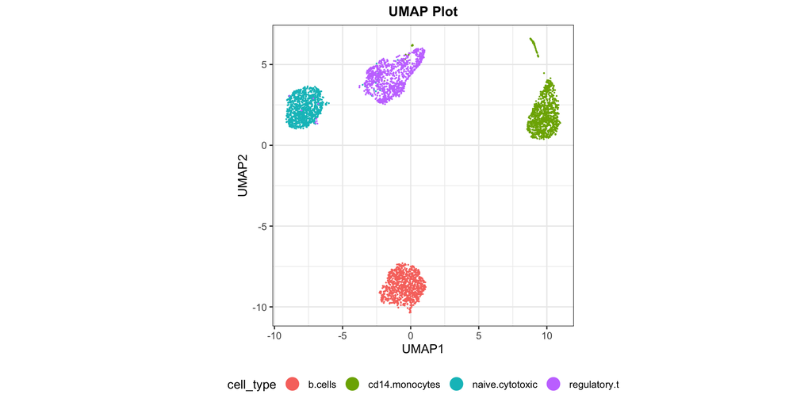

```r
set.seed(123)
S_select <- t(Input_zheng4) %*% W_select
cell_type <- colData(zheng4)$phenoid
umap_select <- data.frame(umap(S_select)$layout, cell_type)
colnames(umap_select) <- c("UMAP1", "UMAP2", "cell_type")

ggplot(umap_select, aes(x=UMAP1, y=UMAP2)) + geom_point(size=0.1, alpha=1, aes(color=cell_type)) +
  ggtitle("UMAP Plot") + theme_bw() +
  theme(aspect.ratio=1, plot.title = element_text(face = "bold", size=12, hjust = 0.5), legend.position = "bottom") +
  guides(color = guide_legend(override.aes = list(size=5)))
```

# 6 Application II: Informative Gene Selection

The most important application of *scPNMF* is to select informative genes (often called highly-variable genes) in an unsupervised way. Compared to other gene selection methods, *scPNMF* works well with a small informative gene number budget. Here we set the pre-specified gene number as $M = 100$.

```r
ig <- getInfoGene(W_select, M = 100, by_basis = FALSE, return_trunW = TRUE, dim_use = NULL)
print(ig$InfoGene)
```

```
##   [1] "ENSG00000116251" "ENSG00000142676" "ENSG00000142669" "ENSG00000169442"
##   [5] "ENSG00000177606" "ENSG00000122406" "ENSG00000163220" "ENSG00000143546"
##   [9] "ENSG00000196154" "ENSG00000143947" "ENSG00000034510" "ENSG00000071082"
##  [13] "ENSG00000197756" "ENSG00000174748" "ENSG00000168028" "ENSG00000188846"
##  [17] "ENSG00000233276" "ENSG00000162244" "ENSG00000182899" "ENSG00000163682"
##  [21] "ENSG00000109475" "ENSG00000145425" "ENSG00000145592" "ENSG00000145741"
##  [25] "ENSG00000019582" "ENSG00000181163" "ENSG00000204628" "ENSG00000206503"
##  [29] "ENSG00000204525" "ENSG00000234745" "ENSG00000227507" "ENSG00000204472"
##  [33] "ENSG00000204287" "ENSG00000198502" "ENSG00000196126" "ENSG00000231389"
##  [37] "ENSG00000223865" "ENSG00000231500" "ENSG00000156508" "ENSG00000205542"
##  [41] "ENSG00000241343" "ENSG00000147403" "ENSG00000133872" "ENSG00000008988"
##  [45] "ENSG00000147604" "ENSG00000070756" "ENSG00000137154" "ENSG00000167996"
##  [49] "ENSG00000251562" "ENSG00000213402" "ENSG00000198851" "ENSG00000167286"
##  [53] "ENSG00000118181" "ENSG00000111348" "ENSG00000111716" "ENSG00000123349"
##  [57] "ENSG00000135390" "ENSG00000196531" "ENSG00000090382" "ENSG00000133639"
##  [61] "ENSG00000150991" "ENSG00000133112" "ENSG00000213741" "ENSG00000196405"
##  [65] "ENSG00000140264" "ENSG00000174444" "ENSG00000140988" "ENSG00000008517"
##  [69] "ENSG00000131143" "ENSG00000051523" "ENSG00000167526" "ENSG00000108298"
##  [73] "ENSG00000173812" "ENSG00000108654" "ENSG00000172809" "ENSG00000132475"
##  [77] "ENSG00000265681" "ENSG00000101439" "ENSG00000171858" "ENSG00000104904"
##  [81] "ENSG00000104964" "ENSG00000233927" "ENSG00000171223" "ENSG00000160888"
##  [85] "ENSG00000105640" "ENSG00000011600" "ENSG00000178982" "ENSG00000130755"
##  [89] "ENSG00000105372" "ENSG00000087086" "ENSG00000142541" "ENSG00000083845"
##  [93] "ENSG00000100097" "ENSG00000100316" "ENSG00000198763" "ENSG00000198804"
##  [97] "ENSG00000198712" "ENSG00000198938" "ENSG00000198886" "ENSG00000198727"
```

The returned object `ig` contains a informative gene vector and a new projection matrix $\mathbf{W}_{S,(M)}$ which only relies on $M$ informative genes.

# 7 Application III: Data Projection

$\mathbf{W}_{S,(M)}$ can be used to project new data. Since it only uses $M$ genes, this projection works for new datasets with only $M$ genes (e.g., single-cell targeted gene profiling). Here we illustrate how the projection works with a subset of the original `zheng4` data that only keeps $M$ genes to mimic the structure of new targeted gene profiling data.

```r
S_new <- getProjection(Input_zheng4[ig$InfoGene, ], ig$trunW)
```

We still use a UMAP plot to visualize the low-dimensional space with $M=100$ genes.

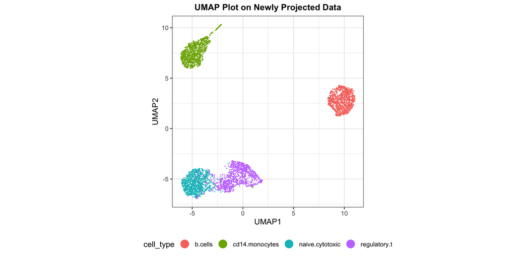

```r
set.seed(456)
cell_type <- colData(zheng4)$phenoid
umap_new <- data.frame(umap(S_new)$layout, cell_type)
colnames(umap_new) <- c("UMAP1", "UMAP2", "cell_type")

ggplot(umap_new, aes(x=UMAP1, y=UMAP2)) + geom_point(size=0.1, alpha=1, aes(color=cell_type)) +
  ggtitle("UMAP Plot on Newly Projected Data") + theme_bw() +
  theme(aspect.ratio=1, plot.title = element_text(face = "bold", size=12, hjust = 0.5), legend.position = "bottom") +
  guides(color = guide_legend(override.aes = list(size=5)))
```

# 8 Getting help

If you meet problems when using *scPNMF*, please report it on issues. For more questions, email us!

# 10 References